# 06_03_Basics_of_Plotting

< [Previous Page](https://wahlerp.github.io/06_02_Matplotlib.html) | [Home Page](https://wahlerp.github.io/) | [Next Page](https://wahlerp.github.io/06_04_Line_Scatter_Plots.html) >

## Let's start plotting

### Basic Plot

A very basic plot can be created using the `.plot()` operator. This creates a simple graph with an x and an y-axis.

```python
import matplotlib as mpl
import matplotlib.pyplot as plt
%matplotlib inline
```

```
[]
```

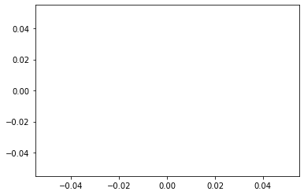

```python
# Create plot with x and y-axis
plt.plot()
```

Looks okay, but not really useful so far. Let's try adding some data to our empty plot. On a still, very basic level, we could try to plot a character "o".

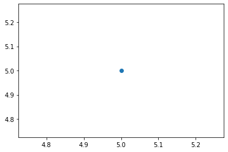

```python
plt.plot(5,5,"o")
```

Awesome! At this point you may wonder how you are supposed to know which potential parameters you can enter into a basic plot. This is where documentation comes in. Simply type in `plt.plot?` and you will get a list of all possible operations of the respective method.

```python
plt.plot?
```

As you can see, there are countless possible options to choose from. This is actually one of the main issues with matplotlib. Due to its huge flexibility, countless options of working with the library exist - this, unfortunately, may become confusing.  
However, **noone expects you to know this stuff by heart**. For working with matplotlib, Googling and looking at the documentation is key - even the pros do it all the time.

### Bacic Plot - Figures and Axes

While the `.plot()` option (as shown in the lecture), is a very straight forward approach to creating a simple graph - we often use `figures` and `axes` instead. In their simplest form, a figure and axes can be created as follows:

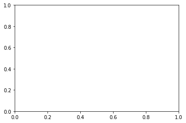

```python
fig = plt.figure()
ax = plt.axes()
```

In Matplotlib, the *figure* (an instance of the class `plt.Figure`) can be thought of as a single container that contains all the objects representing axes, graphics, text, and labels. The *axes* (an instance of the class `plt.Axes`) is what we see above: a bounding box with ticks and labels, which will eventually contain the plot elements that make up our visualization.

Once we have created an axes, we can use the `ax.plot` function to plot some data. Let's plot the same graph again.

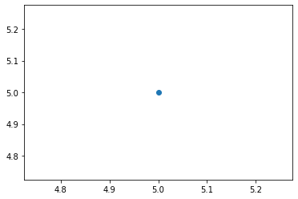

```python
fig = plt.figure()
ax = plt.axes()
ax.plot(5,5, "o")
```

### Basic Plot - Get Current Axes

A third alternative to creating plots is by using the `.gca` (= get current axes) parameter. As stated by its name, this method gets the current Axes instance of the current figure and allows us to store them in a variable.  
This makes our code much cleaner and allows us to apply further operations on our plot. One common addition to the .gca operator, is the use of the .axis() operator, which allows us to change the properties of the axes we just "got". .axis() allows us to specify the minimum and maximum x & y values of our respective graph. Let's look at an example:

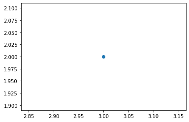

```python
plt.figure()
# plot the point (3,2) using the circle marker
plt.plot(3, 2, 'o')
# get the current axes (we store our plot in the variable "ax")
ax = plt.gca()
# Show our plot
ax
```

So far so good. Let's now use .axis() to change the shown axis to our liking.

```
(0.0, 6.0, 0.0, 10.0)
```

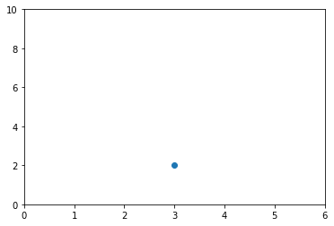

```python
# plot the point (3,2) using the circle marker
plt.plot(3, 2, 'o')
# get the current axes (we store our plot in the variable "ax")
ax = plt.gca()
# Set axis properties [xmin, xmax, ymin, ymax] of our plot (which is stored in "ax")
ax.axis([0,6,0,10])
```

**Exercise For You**  
Look at the following code snippet and try to guess how the resulting plot may look. Then, copy the code, paste it in the empty cell below and check whether you were correct.

```
# plot the point (1.5, 1.5) using the circle marker
plt.plot(1.5, 1.5, 'o')
# plot the point (2, 2) using the circle marker
plt.plot(2, 2, 'o')
# plot the point (2.5, 2.5) using the circle marker
plt.plot(2.5, 2.5, 'o')
```

```python
# test your answer
```

< [Previous Page](https://wahlerp.github.io/06_02_Matplotlib.html) | [Home Page](https://wahlerp.github.io/) | [Next Page](https://wahlerp.github.io/06_04_Line_Scatter_Plots.html) >